# Question 3 — Lending Club: who defaults

Student 25052977

19 June 2026

## The brief

The Director wants to challenge three long-held beliefs and answer some practical questions about default risk. I work on **settled** loans only (outcome known: Fully Paid vs Charged Off / Default); 22.6% of them defaulted.

## Belief 1 — owners and long-tenure staff default less (esp. short-term)

| Term | Homeowner | Tenure | n | default_rate |
| --- | --- | --- | --- | --- |
| 36m (short) | renter/other | <10 yrs / na | 4549 | 0.237 |
| 36m (short) | renter/other | 10+ yrs | 1477 | 0.225 |
| 36m (short) | owner/mortgage | <10 yrs / na | 5422 | 0.168 |
| 36m (short) | owner/mortgage | 10+ yrs | 3369 | 0.142 |
| 60m (long) | renter/other | <10 yrs / na | 1016 | 0.464 |
| 60m (long) | renter/other | 10+ yrs | 393 | 0.438 |
| 60m (long) | owner/mortgage | <10 yrs / na | 1677 | 0.308 |
| 60m (long) | owner/mortgage | 10+ yrs | 1228 | 0.297 |

Home owners and 10+ year employees do default a little less, but the effect is small next to loan term: 60-month loans default far more than 36-month ones in every group. So the belief points the right way, but term matters more than tenure or ownership.

## Belief 2 — states differ in default culture

| State | n | default_rate |
| --- | --- | --- |
| NY | 1460 | 0.282 |
| FL | 1459 | 0.257 |
| MO | 306 | 0.248 |
| NV | 335 | 0.248 |
| MD | 443 | 0.244 |
| CT | 288 | 0.177 |
| SC | 249 | 0.177 |
| CO | 415 | 0.171 |
| WA | 402 | 0.152 |
| OR | 225 | 0.120 |

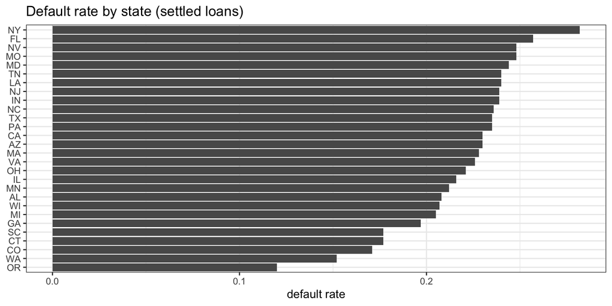

Rates run from 12% to 28%, a real spread of about 16 points. But much of it likely reflects borrower mix (grade, purpose) rather than any geographic “culture”. The difference is genuine but confounded.

## Belief 3 — grade and interest rate predict default

| Grade | n | default_rate | avg_int_rate |
| --- | --- | --- | --- |
| A | 3406 | 0.071 | 6.89 |
| B | 5615 | 0.159 | 10.23 |
| C | 5506 | 0.250 | 13.77 |
| D | 2784 | 0.346 | 18.25 |
| E | 1261 | 0.438 | 22.11 |
| F | 418 | 0.529 | 25.75 |
| G | 141 | 0.582 | 28.88 |

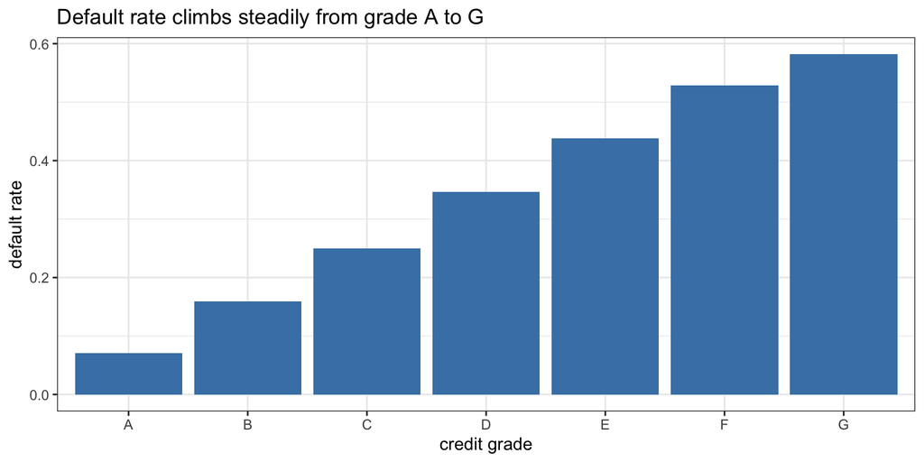

This is the strongest belief, and it holds: default rate rises monotonically from A to G, and interest rate tracks it. Grade and rate clearly carry signal.

## Quantifying the drivers

| driver | odds_ratio | ci_low | ci_high | p_value |
| --- | --- | --- | --- | --- |
| (Intercept) | 0.043 | 0.036 | 0.050 | 0.0000 |
| int_rate | 1.116 | 1.108 | 1.124 | 0.0000 |
| term_months | 1.016 | 1.012 | 1.020 | 0.0000 |
| is_homeownerTRUE | 0.659 | 0.613 | 0.709 | 0.0000 |
| emp_10plusTRUE | 0.909 | 0.841 | 0.981 | 0.0148 |

As odds ratios (>1 raises default odds), interest rate is the single clearest driver: each extra percentage point raises default odds by about 12%, and the 60-month term adds risk, while home ownership and long tenure pull it down.

## Answering the Director

| dti_band | n | default_rate |
| --- | --- | --- |
| 0-10 | 3389 | 0.172 |
| 10-20 | 7764 | 0.201 |
| 20-30 | 5777 | 0.258 |
| 30-40 | 2021 | 0.317 |
| 40+ | 160 | 0.300 |

[figure not shown]

**Does it differ by state? Is Texas different?**

Default rate by DTI band: Texas vs rest

| region | n | default_rate | avg_dti | avg_int_rate |
| --- | --- | --- | --- | --- |
| Rest of US | 17456 | 0.225 | 18.6 | 13.1 |
| Texas | 1675 | 0.235 | 19.5 | 12.9 |

| dti_band | Rest of US | Texas |
| --- | --- | --- |
| 0-10 | 0.173 | 0.158 |
| 10-20 | 0.200 | 0.207 |
| 20-30 | 0.257 | 0.271 |
| 30-40 | 0.318 | 0.309 |
| 40+ | 0.282 | 0.444 |

Texas sits close to the national picture: its overall default rate and DTI curve track the rest of the US, so **one DTI cap fits Texas too**; it doesn’t need its own line.

**Are the Institute’s heuristics realistic?**

- *Owners / long-tenure default less:* true but weak, with a real signal and a small effect.
- *States have a default culture:* overstated; the differences are mostly borrower-mix.
- *Grade and rate predict default:* strongly supported, and the most reliable of the three.

**Who is most likely to default, and what reduces risk?** The highest-risk profile is a low-grade, high-interest, 60-month loan to a renter; the lowest is a top-grade short-term loan to a long-tenure home owner. To reduce risk at assessment, lean on **grade/interest rate and DTI** (the variables that actually carry signal) rather than state or job tenure.

## Limitation

The data has no borrower **age**, so the brief’s “younger borrowers” and “rates set by age/occupation” angles can’t be tested directly, and interest rate stands in as the risk signal. Figures use a 50,000-loan reproducible sample; directions are stable, exact rates shift slightly on the full data.